# Multiple Linear Regression Modelling

## 6.0 Data Modeling

### 6.1 Evaluate Assumptions if to see if transformation is needed to meet model requirement

##### 6.1.1 Additivity Assumption

```r
#symnum correlation table
correlation <- cor(car_transformed_1)#correlation matrix
print(correlation)
```

```
##                    symboling  CarCompany    fueltype  aspiration  doornumber
## symboling         1.00000000  0.31023280  0.24451487  0.09015199  0.64644605
## CarCompany        0.31023280  1.00000000  0.10533519  0.04712168  0.14624690
## fueltype          0.24451487  0.10533519  1.00000000  0.44321239  0.17569492
## aspiration        0.09015199  0.04712168  0.44321239  1.00000000  0.07157448
## doornumber        0.64644605  0.14624690  0.17569492  0.07157448  1.00000000
## carbody           0.40905124  0.16196708  0.15621108  0.05946625  0.43182282
## drivewheel       -0.09356838 -0.04023801 -0.15492967 -0.14942920  0.09177862
## enginelocation   -0.17323229  0.03349600 -0.03707185 -0.05117663 -0.12909944
## wheelbase         0.60116041  0.12117265  0.36041222  0.33022591  0.47482063
## carlength         0.47412319  0.15346423  0.26653273  0.28462906  0.45999061
## carwidth          0.35853754  0.01006971  0.31508578  0.38340473  0.32054167
## carheight         0.62746856  0.21491709  0.30046482  0.09304092  0.55327103
## curbweight        0.36990117  0.06607403  0.30342783  0.42729783  0.27690905
## enginetype        0.16298358  0.14483307  0.09437776  0.09855397  0.15591202
## cylindernumber   -0.04192390 -0.29117089  0.08912424  0.04777138 -0.01392439
## enginesize        0.22277887 -0.02594277  0.16399089  0.23628276  0.09647511
## fuelsystem       -0.06693067 -0.09077682  0.64493057  0.50597914 -0.06223228
## boreratio         0.34628111  0.32776390  0.08273042  0.25250670  0.17492154
## stroke           -0.04468670 -0.17907919  0.26419271  0.24989333 -0.09038988
## compressionratio  0.23676874  0.12899745  0.98709302  0.34279144  0.16699287
## horsepower        0.02283575 -0.02028796 -0.14255925  0.31886077 -0.03086476
## peakrpm          -0.34942186 -0.22778666 -0.48560954 -0.21103714 -0.24464103
## citympg          -0.05672005  0.05691444  0.26074165 -0.23344758 -0.05861676
## highwaympg       -0.11734092  0.04233517  0.17745673 -0.29935120 -0.07741217
## price             0.20090466 -0.11335624  0.20899254  0.33310510  0.15409159
##                      carbody  drivewheel enginelocation    wheelbase
## symboling         0.40905124 -0.09356838    -0.17323229  0.601160406
## CarCompany        0.16196708 -0.04023801     0.03349600  0.121172649
## fueltype          0.15621108 -0.15492967    -0.03707185  0.360412215
## aspiration        0.05946625 -0.14942920    -0.05117663  0.330225906
## doornumber        0.43182282  0.09177862    -0.12909944  0.474820632
## carbody           1.00000000 -0.09380151     0.27834677  0.353869141
## drivewheel       -0.09380151  1.00000000    -0.14274929 -0.458184624
## enginelocation    0.27834677 -0.14274929     1.00000000 -0.170037787
## wheelbase         0.35386914 -0.45818462    -0.17003779  1.000000000
## carlength         0.39889188 -0.49608241    -0.04042397  0.871916023
## carwidth          0.24005506 -0.44905090    -0.04054040  0.836427142
## carheight         0.47739019 -0.04147710    -0.09824077  0.660601202
## curbweight        0.29332463 -0.60726811     0.05872814  0.798584904
```

[output cut: 101 more lines]

```
## carwidth         -0.58981091 -0.63357161  0.74757501
## carheight        -0.10312386 -0.16699987  0.26102906
## curbweight       -0.73053255 -0.77459486  0.83370382
## enginetype        0.01064854 -0.02160484 -0.01263639
## cylindernumber   -0.50162530 -0.51914192  0.60094695
## enginesize       -0.65528443 -0.66594990  0.82962892
## fuelsystem        0.25527379  0.20536281 -0.07069035
## boreratio        -0.55932655 -0.57635404  0.50857757
## stroke           -0.05259807 -0.03609808  0.08927276
## compressionratio  0.33244014  0.25222647  0.16542447
## horsepower       -0.81965202 -0.79681848  0.77646492
## peakrpm          -0.09968137 -0.05170261 -0.10547612
## citympg           1.00000000  0.96813618 -0.66924795
## highwaympg        0.96813618  1.00000000 -0.68576238
## price            -0.66924795 -0.68576238  1.00000000
```

```r
symnum(correlation,symbols = c("| ", ".", ",", "+", "*", "B"))
```

```
##                  sy C  flt a  drn crbd drv engnl w  crl crw crh crbw engnt cy
## symboling        1
## CarCompany       .  1
## fueltype         |  |  1
## aspiration       |  |  .   1
## doornumber       ,  |  |   |  1
## carbody          .  |  |   |  .   1
## drivewheel       |  |  |   |  |   |    1
## enginelocation   |  |  |   |  |   |    |   1
## wheelbase        ,  |  .   .  .   .    .   |     1
## carlength        .  |  |   |  .   .    .   |     +  1
## carwidth         .  |  .   .  .   |    .   |     +  +   1
## carheight        ,  |  .   |  .   .    |   |     ,  .   .   1
## curbweight       .  |  .   .  |   |    ,   |     ,  +   +   .   1
## enginetype       |  |  |   |  |   |    |   |     |  |   |   |   |    1
## cylindernumber   |  |  |   |  |   |    .   |     .  .   .   |   .    |     1
## enginesize       |  |  |   |  |   |    .   |     .  ,   ,   |   +    |     .
## fuelsystem       |  |  ,   .  |   |    |   |     |  |   |   |   |    |     |
## boreratio        .  .  |   |  |   |    .   |     .  ,   .   |   ,    .     |
## stroke           |  |  |   |  |   |    |   |     |  |   |   |   |    .     |
## compressionratio |  |  B   .  |   |    |   |     .  |   |   |   |    |     |
## horsepower       |  |  |   .  |   |    .   .     .  .   .   |   ,    |     .
## peakrpm          .  |  .   |  |   |    |   |     .  .   |   .   |    |     |
## citympg          |  |  |   |  |   |    .   |     .  ,   .   |   ,    |     .
## highwaympg       |  |  |   |  |   |    .   |     .  ,   ,   |   ,    |     .
## price            |  |  |   .  |   |    .   .     .  ,   ,   |   +    |     ,
##                  engns fls b  st cm hr pk ct hg pr
## symboling
## CarCompany
## fueltype
## aspiration
## doornumber
## carbody
## drivewheel
## enginelocation
## wheelbase
## carlength
## carwidth
## carheight
## curbweight
## enginetype
## cylindernumber
## enginesize       1
## fuelsystem       |     1
## boreratio        .     |   1
## stroke           |     .   |  1
## compressionratio |     .   |  |  1
## horsepower       +     |   .  |  |  1
## peakrpm          |     |   .  |  .  |  1
## citympg          ,     |   .  |  .  +  |  1
## highwaympg       ,     |   .  |  |  ,  |  B  1
## price            +     |   .  |  |  ,  |  ,  ,  1
## attr(,"legend")
## [1] 0 '| ' 0.3 '.' 0.6 ',' 0.8 '+' 0.9 '*' 0.95 'B' 1
```

Singularity between Conpressionratio and fuel type, highwaympg and citympg The additivity assumption is not met if both Conpressionratio and fuel type or highwaympg and citympg included in the model at the same time. since they have high correlation, it will cause reduce power of the model.

##### 6.1.2 Linearity assumption

```r
M_1 <- lm(price ~ ., data = car_nooutliers)

summary(M_1, correlation = TRUE)
```

```
##
## Call:
## lm(formula = price ~ ., data = car_nooutliers)
##
## Residuals:
##      Min       1Q   Median       3Q      Max
## -2061.04  -554.55    67.44   581.56  2298.49
##
## Coefficients: (7 not defined because of singularities)
##                             Estimate Std. Error t value Pr(>|t|)
## (Intercept)               -1.505e+04  1.192e+04  -1.263 0.209100
## symboling-1                5.282e+02  8.103e+02   0.652 0.515719
## symboling0                -4.210e+02  9.580e+02  -0.440 0.661071
## symboling1                -6.966e+02  1.002e+03  -0.695 0.488136
## symboling2                -4.740e+02  1.067e+03  -0.444 0.657660
## symboling3                -7.617e+01  1.117e+03  -0.068 0.945753
## CarCompanyaudi             9.487e+02  1.748e+03   0.543 0.588299
## CarCompanybmw              1.170e+04  2.079e+03   5.626 1.20e-07 ***
## CarCompanybuick            2.210e+03  1.855e+03   1.191 0.235780
## CarCompanychevrolet       -3.054e+03  1.686e+03  -1.811 0.072555 .
## CarCompanydodge           -4.573e+03  1.427e+03  -3.205 0.001722 **
## CarCompanyhonda           -3.012e+03  1.559e+03  -1.932 0.055688 .
## CarCompanyisuzu           -1.274e+03  1.601e+03  -0.796 0.427671
## CarCompanymazda           -1.043e+03  1.403e+03  -0.744 0.458591
## CarCompanymitsubishi      -5.226e+03  1.435e+03  -3.641 0.000399 ***
## CarCompanynissan          -3.615e+02  1.409e+03  -0.257 0.797866
## CarCompanypeugeot         -3.285e+03  1.871e+03  -1.756 0.081601 .
## CarCompanyplymouth        -4.641e+03  1.391e+03  -3.336 0.001127 **
## CarCompanyporsche          2.009e+04  2.316e+03   8.677 2.13e-14 ***
## CarCompanyrenault         -1.774e+03  1.728e+03  -1.027 0.306655
## CarCompanysaab             1.372e+03  1.901e+03   0.722 0.471841
## CarCompanysubaru           1.269e+03  1.857e+03   0.683 0.495710
## CarCompanytoyota          -1.493e+03  1.340e+03  -1.114 0.267509
## CarCompanyvolkswagen      -1.730e+03  1.419e+03  -1.219 0.225153
## CarCompanyvolvo           -3.804e+02  2.014e+03  -0.189 0.850466
## fueltypegas                1.031e+03  4.729e+03   0.218 0.827847
## aspirationturbo            1.534e+03  5.625e+02   2.728 0.007320 **
## doornumber4 doors          1.838e+01  3.357e+02   0.055 0.956434
## carbodyhardtop            -2.327e+03  1.037e+03  -2.245 0.026596 *
## carbodyhatchback          -2.443e+03  8.665e+02  -2.820 0.005613 **
```

[output cut: 1015 more lines]

```
## enginetypeohcv
## enginetyperotor
## cylindernumber4 cylinders
## cylindernumber5 cylinders
## cylindernumber6 cylinders
## enginesize
## fuelsystem2bbl
## fuelsystemmpfi
## boreratio
## stroke
## compressionratio
## horsepower
## peakrpm                   -0.44
## citympg                    0.08      -0.03
## highwaympg                -0.11       0.12   -0.82
```

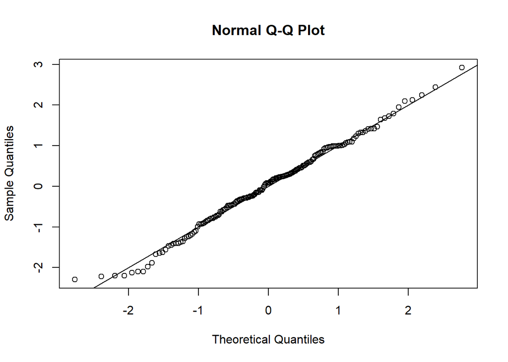

```r
#Assumption Set Up
standardized <- rstudent(M_1)
fitted <- scale(M_1$fitted.values)#

{qqnorm(standardized)
  abline(0,1)}
```

The assumption for linearity is met, the data points follows the reference line, only the points at two ends (below -2 and above 2) deviate

##### 6.1.3 Normality Assumption

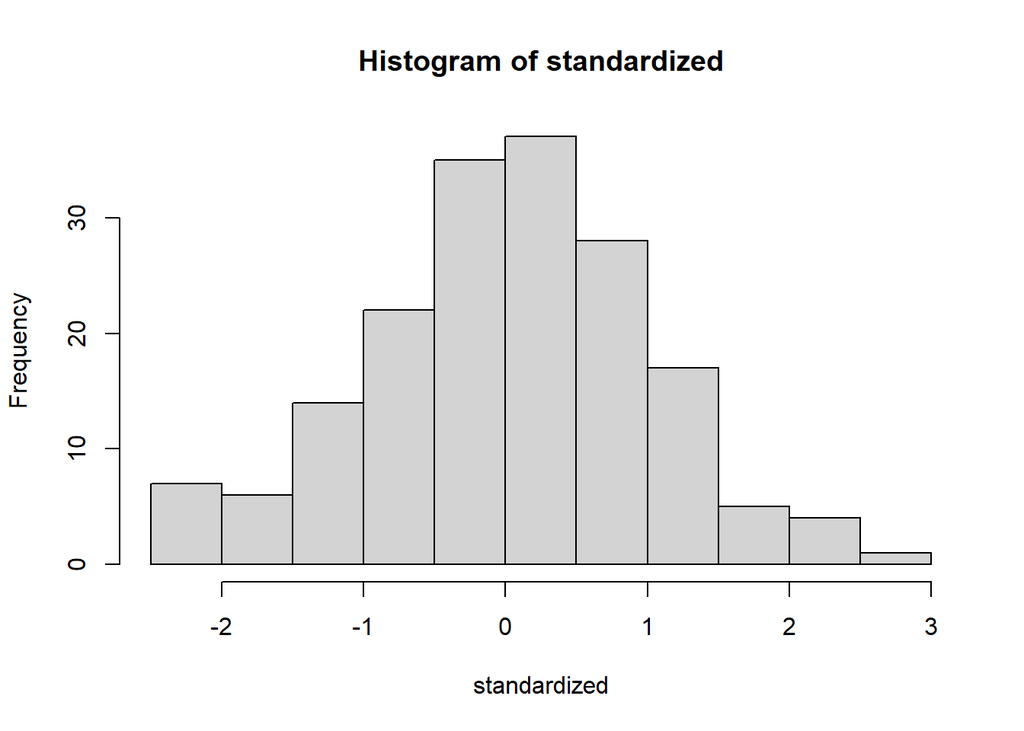

```r
hist(standardized)
```

The assumption for normality is met, the histogram shows a bell curve shape indicating the data are approximately normal distributed.

##### 6.1.4 Homogeneity and Homoscedasticity Assumption

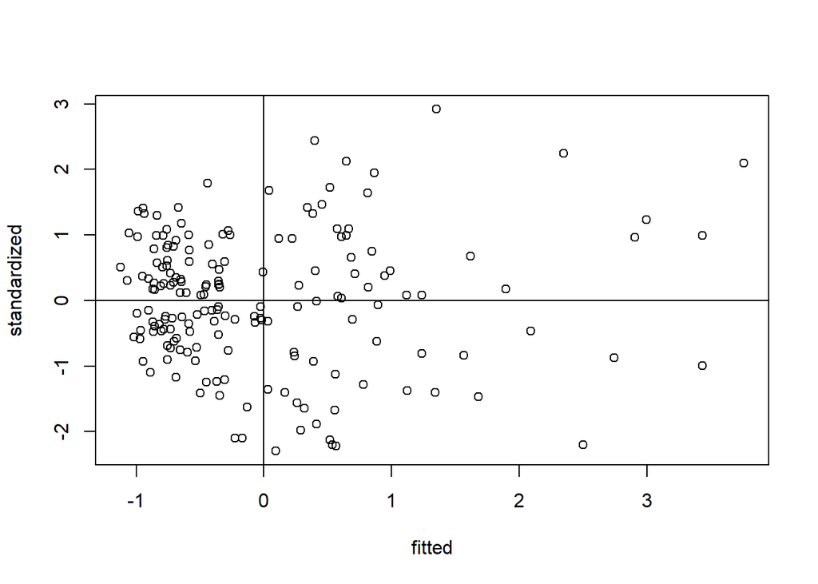

```r
{plot(fitted, standardized)
  abline(0,0)
  abline(v = 0)}
```

Since the assumptions are met, data transformation is not needed.